# On Integrating a Function w.r.t. a Multivariate Gaussian

Eric Wang

1/3/2018

Sometime a statistician might want to numerically evaluate the convolution of some function and a multivariate Gaussian density. Feasible numerical tools exist when the dimension of the Gaussian is lower than 4. This could arise, say, when you are trying to fit a log Gaussian mixture of Poisson model. In this post I will use this model as an example and present a little trick in doing such numerically convolution.

## Log-Gaussian Mixutre of Poisson

Without the loss of generality, I will simply focus on the 2-dimenisional case. The model is given by

`y_i1 ~ Poisson(e^x_i1), y_i2 ~ Poisson(e^x_i2)`

`c(x_i1,x_i2) ~ N(mu, S),`

where `mu` and `S` are the parameters of the model.

The likelihood of `c(y_i1,y_i2)` is the following integral

`f(y_i1|e^x_i1)f(y_i2|e^x_i2)phi(x_i1,x_i2|mu, S)`

w.r.t. `x_i1` and `x_i2`, where `f` is the density function of Poisson and `phi` is the density function for 2-dimensional Gaussian. As can be easily seen, this integral does not have an analytical form. But fortunately we could approximate this integral via numerical methods.

## Simpson Quadrature with De-correlation

Simpson quadrature is the one of the popular tools for multivariate integration. It works well when the dimension is low, but quickly become infeasible when the dimension is high. In fact, when the dimension is high, nothing but Monte Carlo type of integration works.

However, even in 2-dimensional case, a naive implementation could be problematic, here is an intuitive example.

I first write a Monte Carlo integration function and use it as the ground truth. So that I can measure if the naive Simpson quadrature is doing a good job or not.

```r
monteCarlo <- function(nmc, y, mu, S) {
  # simulate x from the Gaussian
  x = rmvnorm(nmc, mu, S)
  # map these x via the function and then average
  mean(dpois(y[1], exp(x[,1]))*dpois(y[2], exp(x[,2])))
}
```

And here is the naive Simpson quadrature method.

```r
naiveQuad2d <- function(y, mu, S) {
  # first define the integrand, note that the two variables of the function need
  # to be vectorized
  integrand <- function(x1, x2) {
    dpois(y[1], exp(x1))*dpois(y[2], exp(x2))*dmvnorm(cbind(c(x1),c(x2)), mu, S)
  }
  # finite lower and upper bounds have to be provided for quad2d
  # in our case we set it to be 10 sd away from the center to make sure that
  # the function value is negligible
  quad2d(integrand, mu[1]-10*sqrt(S[1,1]), mu[1]+10*sqrt(S[1,1]),
         mu[2]-10*sqrt(S[2,2]), mu[2]+10*sqrt(S[2,2]), 64)
}
```

The quadrature does not always work. Let’s fix `mu` and the diagonal elements of `S` but vary the off-diagonal element, or equivalently, vary the correlation.

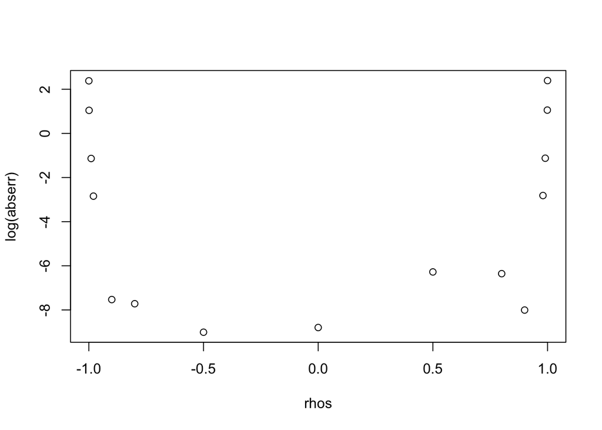

```r
# fix y, mu and the diagonal elements of S
y = c(0,0)
mu = c(-3,-3)
diag_S = c(1, 1)
nmc = 10000 # number of simulations to be made in Monte Carlo
# but vary the correlation
rhos = c(-.9999,-.999,-.99,-.98,-.9,-.8,-.5,0,.5,.8,.9,.98,.99,.999,.9999)
abserr = NULL
for (rho in rhos) {
  S = diag(sqrt(diag_S))%*%matrix(c(1,rho,rho,1),2,2)%*%diag(sqrt(diag_S))
  abserr = c(abserr, abs(naiveQuad2d(y, mu, S) - monteCarlo(nmc, y, mu, S)))
}
plot(rhos, log(abserr))
```

Why? Simpson quadrature is sampling a bunch of functional values on a 2-dimensional grid. But what happened when `x_i1` and `x_i2` are highly correlated? The major mass roughly falls on a single line in the 2-dimensional space, hence the naively chosen 2-d grid will not work well. We need to de-correlate `x_i1` and `x_i2` so that the function is roughly “evenly distributed”

## Choleski Factorization & Change of Variable

In order to de-correlate, we need a tiny bit of algebra, the Choleski factorization; and a tiny bit of a calculus, change of variables.

```r
cholQuad2d <- function(y, mu, S) {
  # now we first compute the Choleski factorization of S
  upper_tri = chol(S)
  integrand <- function(z1, z2) {
    # change of variables
    x1 = mu[1]+upper_tri[1,1]*z1+upper_tri[2,1]*z2
    x2 = mu[2]+upper_tri[1,2]*z1+upper_tri[2,2]*z2
    # don't forget the Jacobian
    dpois(y[1], exp(x1))*dpois(y[2], exp(x2))*dmvnorm(cbind(c(x1),c(x2)), mu, S)*det(upper_tri)
    # note that dmvnorm(cbind(c(x1),c(x2)), mu, S)*det(upper_tri) equals dnorm(z1)*dnorm(z2)
  }
  # finite lower and upper bounds have to be provided for quad2d
  # in our case we set it to be 10 sd away from the center to make sure that
  # the function value is negligible
  quad2d(integrand, -10, 10, -10, 10, 64)
}
```

And this time, the accuracy is much better :)

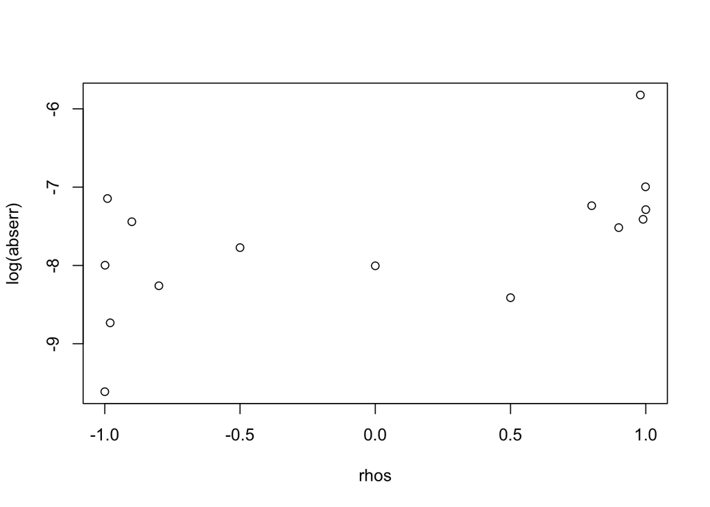

```r
# fix y, mu and the diagonal elements of S
y = c(0,0)
mu = c(-3,-3)
diag_S = c(1, 1)
nmc = 10000 # number of simulations to be made in Monte Carlo
# but vary the correlation
rhos = c(-.9999,-.999,-.99,-.98,-.9,-.8,-.5,0,.5,.8,.9,.98,.99,.999,.9999)
abserr = NULL
for (rho in rhos) {
  S = diag(sqrt(diag_S))%*%matrix(c(1,rho,rho,1),2,2)%*%diag(sqrt(diag_S))
  abserr = c(abserr, abs(cholQuad2d(y, mu, S) - monteCarlo(nmc, y, mu, S)))
}
plot(rhos, log(abserr))
```